# Introduction to Data Analysis in the R Programming Language

Mary Alldred

last updated 11/12/2025

# Learning Objectives

> - Learn basic syntax of the R programming language.
> - Import, subset, and inspect data in R.
> - Produce scatter plots, boxplots, and bar graphs using `ggplot2`, part of the `tidyverse` package.
> - Customize and export graphs.
> - Perform simple statistical tests (*e.g.*, t-test, ANOVA, and linear regression) and interpret output.

# Setting up R and RStudio

You will have two options for the activity today. You may:

1. Conduct the activity on a computer in the GIS or Miner computer classroom. Login to your Google Drive Desktop.
2. Install or update R and RStudio on your own computer. https://datacarpentry.org/R-ecology-lesson/

First, download the “RDataAnalysis” folder from Brightspace to your computer. If you are working on a classroom computer, unzip the folder to your Google Drive “My Drive” folder. If you are working on your own computer, you can save the folder in a directory that makes sense for you, but be sure you can locate it!

In RStudio, you should select `File` -> `New Project` -> `Existing Directory`, and navigate to the “RDataAnalysis” folder on the computer you are using.

Once you have started a new project, you should click on the icon and select `R Script`. This will provide you with a workspace where you can type and save code. Once you have opened a new script, you should see four main panels in your RStudio window:

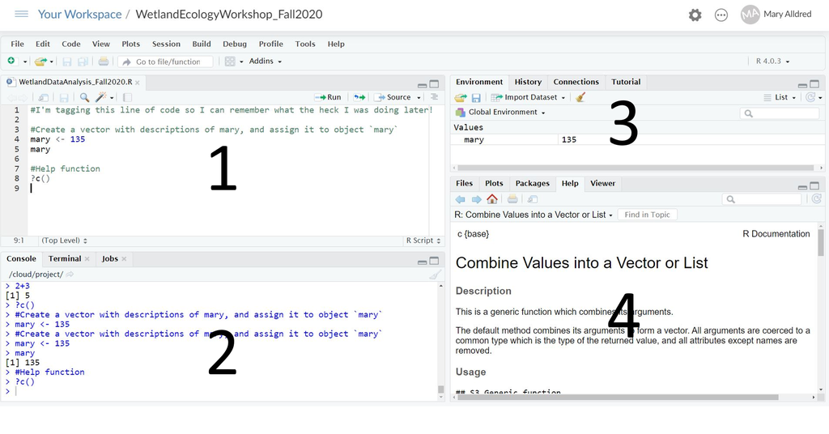

1. The script
2. The console
3. The environment
4. A panel with Files, Plots, Packages, Help, and Viewer

## The script

You can think of the script as your work space. Here, you can enter, run, and save code. I recommend you **never delete** any code that works from your script. You can always copy and paste code and then make changes. It is good practice to leave space between code chunks and tag lines using a `#`. R will skip lines that begin with `#` when running code. You can run any line of code by placing your cursor on the line and hitting `Ctrl` + `Enter`.

```r
# I have tagged this line of code so that I can remember what I was doing when I come back to this project later!
```

Go ahead and **save** your script now. Hit `Ctrl` + `s`. You will notice that this opens your project folder. Save your script as something sensible, *e.g.*, “WetlandsDataAnalysis”. This will save your script as a .R file, which you can save and reopen at any time. Notice that if you have unsaved changes in your script, the title on the tab will appear in red with a * at the end of the file name. When you save changes (`Ctrl` + `s`), the title will appear black again. It’s good practice to save your changes at the end of a code block or every ~15 min.

## The console

The console will show the output for code that you run. Code that has run will show up in blue (default). Warnings, errors, and messages will show up in red. Output will show up in black.

## The environment

The environment will show a list of any objects or functions that you create. In R, we create objects by giving them a name, and then using `<-` to assign something to that name. For example, in the code below, I create an object named `mary` and assign the number 135 (my office number in Hudson) to the object.

```r
mary <- 135
mary
```

```
## [1] 135
```

Once I have created this object, it shows up in my Environment panel as object `mary`. I can call that object by typing the object name `mary`, and hitting `Ctrl` + `Enter`. When you run this code, you should see the output `135` appear in the console.

## Files, Plots, Packages, Help, Viewer

The **Files** panel shows you all of the folders and files in your project. The **Plots** panel shows plots that you create. You can use the arrow buttons to revisit previous plots. The **Packages** panel shows a list of packages that you have installed. Packages contain additional functions programmers have written that can help you to tidy your data, make pretty graphs, or run more complicated analyses. You can install and update packages here, or attach and detach packages from your project. However, it is best practice to load packages from your *script* so that you will have a record of packages that you need to run your code. We will cover how to install and load a package later in this workshop. The **Help** panel will display help files. This tool is very useful for exploring options for functions that you use, or for help in interpreting output. Type `?c()` into your script and run it to pull up the help file for the concatenate function, the first function we will use in this workshop.

# Objects and Vectors

R is an object-oriented language. That means you can assign anything to an object and refer to that object later. Here I create a vector that includes nine numbers using the concatenate function, `c()`. I will assign that vector to an object. Note that anytime you create a new object, it will appear in the Environment box in the upper right corner of R Studio.

```r
# Create a vector of numbers, and name that vector num
num <- c(5, 6, 9, 8, 5, 6, 3, 7, 8)
# Run num to see vector output
num
```

```
## [1] 5 6 9 8 5 6 3 7 8
```

## Challenge 1

> Create an object that represents your age.  
> Create an object that represents the age of a friend/roommate.  
> Copy and paste your code to the Challenge 1 question on Brightspace. (Hint: double tag ## your challenge answers in your script and copy and paste them to Brightspace later.)

**Click for a hint**

```r
# Create object mary that represents my age
mary <- 38.9
# Create object jon that represents Jon's age
jon <- 36.5
```

You can use R to do math! I will refer to my `num` vector and use the `mean()` and `sd()` functions to calculate the mean and standard deviations of those numbers. I can also use the `length()` function to count the number of items in my vector.

```r
#Calculate the mean and standard deviation of vector num.
mean(num)
```

```
## [1] 6.333333
```

```r
sd(num)
```

```
## [1] 1.870829
```

```r
length(num)
```

```
## [1] 9
```

## Challenge 2

> Add your age to the age of your friend by referencing the objects you created in Challenge 1.  
> Create a vector that contains both of your ages by referencing the objects, and save the vector as an object.  
> Copy and paste your code to the Challenge 2 question on Brightspace

**Click for a hint**

```r
# Add ages of mary and jon
mary + jon
```

```
## [1] 75.4
```

```r
# Create vector that contains both ages
both <- c(mary, jon)
```

Characters can also be included in vectors using quotation marks. Note that if any item in a vector is a character string, then all of the items in the vector will be converted to characters. Columns in a data frame that contain categorical variables (*e.g.*, color, month, etc.) will appear as character vectors.

```r
# Create a vector of color names
col <- c("red", "blue", "yellow")
# Execute code
col
```

```
## [1] "red"    "blue"   "yellow"
```

```r
# Create a vector of color names that also contains a number
colnum <- c("red", "blue", "yellow", 5)
# Execute code.  Note that 5 has been converted to character string "5".
colnum
```

```
## [1] "red"    "blue"   "yellow" "5"
```

## Indexing

In R, parentheses are used for functions, *e.g.*, `c()`, `mean()`, `sd()`. Brackets `[]` are used for indexing. I can use brackets after the name of my vector to identify items at that position.

```r
# Reference the item in the third position of vector num
num[3]
```

```
## [1] 9
```

```r
# Reference the item in the first position of vector col
col[1]
```

```
## [1] "red"
```

## Challenge 3

> Create an object that represents a sequence from 1 to 100 in units of 0.5 using the `seq()` function. Form: `seq(first value, last value, interval)`.  
> Find the 9th and 12th positions of your sequence.  
> Find the 9th and 12th positions of your sequence using one line of code (Hint: use `c()` to make a vector that specifies the positions you want.) Copy and paste your code to the Challenge 3 question on Brightspace.

**Click for a hint**

```r
# Create sequence from 1 to 100 in increments of 05
s <- seq(1, 100, 0.5)
# Find 9th position
s[9]
```

```
## [1] 5
```

```r
# Find 12th position
s[12]
```

```
## [1] 6.5
```

```r
# Find 9th and 12th position
s[c(9, 12)]
```

```
## [1] 5.0 6.5
```

## Arguments

Arguments are added within functions to tell the function what to do. You can customize functions by changing arguments; this makes functions flexible. For example, I can use the argument `na.rm = TRUE` to tell the `mean()` function to ignore missing values, or NAs.

```r
# Create a vector that has a missing value, or NA
nanum <- c(5, 7, NA, 10, 12, 5, 7)
# Calculate the mean of this vector using unmodified mean() function
mean(nanum)
```

```
## [1] NA
```

```r
# Calculate the mean, adding argument na.rm = TRUE to tell mean() function to ignore NA values
mean(nanum, na.rm = T)
```

```
## [1] 7.666667
```

# Getting Help!

Every function is associated with a help file. You can type `?function()` to pull up the help file on the function. The help file will appear in the help viewer in the bottom right of your RStudio window. Help files generally contain examples at the end that you can copy and paste into your script to test the function. They also include arguments you can use to modify how the function works.  
If you are unsure exactly what to look for, you can type `??function` to pull up search results on that term. Most developers include help files for new functions in packages. R also has an extensive community online. Google “calculate mean in R” to see wealth of information available. Most coding problems can be solved by looking up previous solutions online.  
**Note: Beware of using AI to solve coding problems!** Sometimes it works well, sometimes it doesn’t. Often it will give you very a complicated (or wrong) solution to a very simple problem, especially when you are first starting out. The good thing about using online resources like Stack Exchange is that they were written by coders who explain the approach they would use, and folks can provide feedback on better solutions or caution users if posted solutions are wrong or misleading.

```r
?mean()
??mean
```

# Using R Packages

You can download new packages to make use of functions that clever programmers have written for R. Today, we will use the `tidyverse` package. It contains a number of packages with useful tools for data manipulation and graphing.  
Use the `library()` function to load packages that you want to use. When a package is loaded, it will be checked in the Packages tab in the bottom right corner in R Studio.  
If the package does not load, you may need to install it. Make sure the package is NOT listed in the Packages panel before you install it. Use the `install.packages()` function to install new packages to R. It may take a while. If it asks you to update packages during the installation process, the safest answer is **no**. When the package has finished installing, you will see it appear in your User Library in the Packages tab in bottom right corner of RStudio. You should now be able to use `library()` to load your new package.

```r
# Use library function to load tidyverse
library(tidyverse)
# Use install.packages("tidyverse") function to install tidyverse if necessary
```

# Importing data from .csv files

The easiest way to read data into R is to save the data to a **.csv** text file in Excel. The data should be formatted so that variables appear as separate columns and each observation appears on a new row. Note that .csv files do not support multiple tabs. You will need to save each tab that you need to a separate .csv file. Formulas are also not retained in .csv files. Therefore, it is good practice to also keep a copy of the original Excel .xlsx files if you have calculated columns.  
If you are working in RStudio desktop, you need only save your .csv files to your project folder on your computer. Once you have done this they should appear in the **Files** panel in your workspace.  
You may import files using the `read.csv()` function. You should assign your data to an object that you can easily reference later in your code. Give some thought to what you call your data; it should be obvious what the object refers to, but long object names will be annoying to type over and over.

```r
# Import Altona Flat Rock soil data
soil <- read.csv("AltonaSoilData_2025.csv")
# Import pitcher plant nutrient data
nut <- read.csv("PitcherPlant_Nutrients_2025.csv")
# Import pitcher plant community data
com <- read.csv("PitcherPlant_Community_2025.csv")
# Import macroinvertebrate data
mac <- read.csv("Macroinvertebrates_2025.csv")
```

## Inspect data frames

You should always inspect data frames once you have imported them to make sure they look the way you expect. You can pull up the entire data frame from the “Environment” box in RStudio by clicking on the object name. This works well for small data frames.  
The structure function `str()` is useful for quickly looking at characteristics of your data frame. It lists each variable in your data frame, as well as the type of variable it is. For factors, it provides the number of levels, or categories. You can also use the `head()` function to look at the first few rows of your data frame or the `tail()` function to look at the last few rows of your data frame. The `summary()` function provides summary statistics for each variable in your data frame.

```r
#Inspect soil data frame
str(soil)
head(soil)
tail(soil)
summary(soil)
```

## Challenge 4

> Use the `str()` function to inspect the `soil` data frame.  
> What type of variable is `Treatment`?  
> How many rows are in the data frame?  
> How many columns are in the data frame?  
> Enter your answers into the Challenge 4 question on Brightspace.

**Click for a hint**

```r
# Use str to inspect soil data frame
str(soil)
```

```
## 'data.frame':    40 obs. of  7 variables:
##  $ Code              : chr  "FA00" "FA05" "FA10" "FA15" ...
##  $ Treatment         : chr  "Fire" "Fire" "Fire" "Fire" ...
##  $ Site              : chr  "Beaver Pond" "Beaver Pond" "Beaver Pond" "Beaver Pond" ...
##  $ TransectPosition_m: int  0 5 10 15 20 0 5 10 15 20 ...
##  $ BulkDensity_gcm3  : num  0.124 0.223 0.569 0.599 0.505 ...
##  $ Moisture          : num  0.932 0.714 0.539 0.44 0.456 ...
##  $ Organic           : num  0.763 0.93 0.37 0.297 0.321 ...
```

## Indexing data frames

You can use brackets to index certain rows and/or columns in data frames just as you used them to index certain items in a vector. The format is `dataframe[row,column]`. You can reference by number or by name. You can also use the special format `df$column` to call columns.

```r
# Reference the third observation of soil density in the soil data frame
soil[3, "BulkDensity_gcm3"]
# Reference all values for the third row in the soil data frame
soil[3,]
# Reference all values of soil density in the soil data frame
soil[, "BulkDensity_gcm3"]
soil$BulkDensity_gcm3
# You can also use logic statements to select certain rows
# The following will select any rows for which the soil density was greater than 0.5
soil[soil$BulkDensity_gcm3 >= 0.5,]
# You can use any of the inspection functions to look at a single column/variable.
str(soil$BulkDensity_gcm3)
summary(soil$BulkDensity_gcm3)
hist(soil$BulkDensity_gcm3)
```

## Changing/Adding Variables

You can use object assignment to change the properties of variables in your data frame or to add new calculated columns to the data frame. Below is an example of changing a character to an ordered factor and calculating percent moisture.

```r
# Change Treatment to an ordered factor
soil$Treatment <- ordered(soil$Treatment, levels = c("Fire", "Control"))
# Inspect structure of soil data frame again
str(soil)
```

```
## 'data.frame':    40 obs. of  7 variables:
##  $ Code              : chr  "FA00" "FA05" "FA10" "FA15" ...
##  $ Treatment         : Ord.factor w/ 2 levels "Fire"<"Control": 1 1 1 1 1 1 1 1 1 1 ...
##  $ Site              : chr  "Beaver Pond" "Beaver Pond" "Beaver Pond" "Beaver Pond" ...
##  $ TransectPosition_m: int  0 5 10 15 20 0 5 10 15 20 ...
##  $ BulkDensity_gcm3  : num  0.124 0.223 0.569 0.599 0.505 ...
##  $ Moisture          : num  0.932 0.714 0.539 0.44 0.456 ...
##  $ Organic           : num  0.763 0.93 0.37 0.297 0.321 ...
```

```r
# Calculate PcntMoisture as a percentage by multiplying by 100
soil$PcntMoisture <- soil$Moisture * 100
# Inspect structure of soil data frame again
str(soil)
```

```
## 'data.frame':    40 obs. of  8 variables:
##  $ Code              : chr  "FA00" "FA05" "FA10" "FA15" ...
##  $ Treatment         : Ord.factor w/ 2 levels "Fire"<"Control": 1 1 1 1 1 1 1 1 1 1 ...
##  $ Site              : chr  "Beaver Pond" "Beaver Pond" "Beaver Pond" "Beaver Pond" ...
##  $ TransectPosition_m: int  0 5 10 15 20 0 5 10 15 20 ...
##  $ BulkDensity_gcm3  : num  0.124 0.223 0.569 0.599 0.505 ...
##  $ Moisture          : num  0.932 0.714 0.539 0.44 0.456 ...
##  $ Organic           : num  0.763 0.93 0.37 0.297 0.321 ...
##  $ PcntMoisture      : num  93.2 71.4 53.9 44 45.6 ...
```

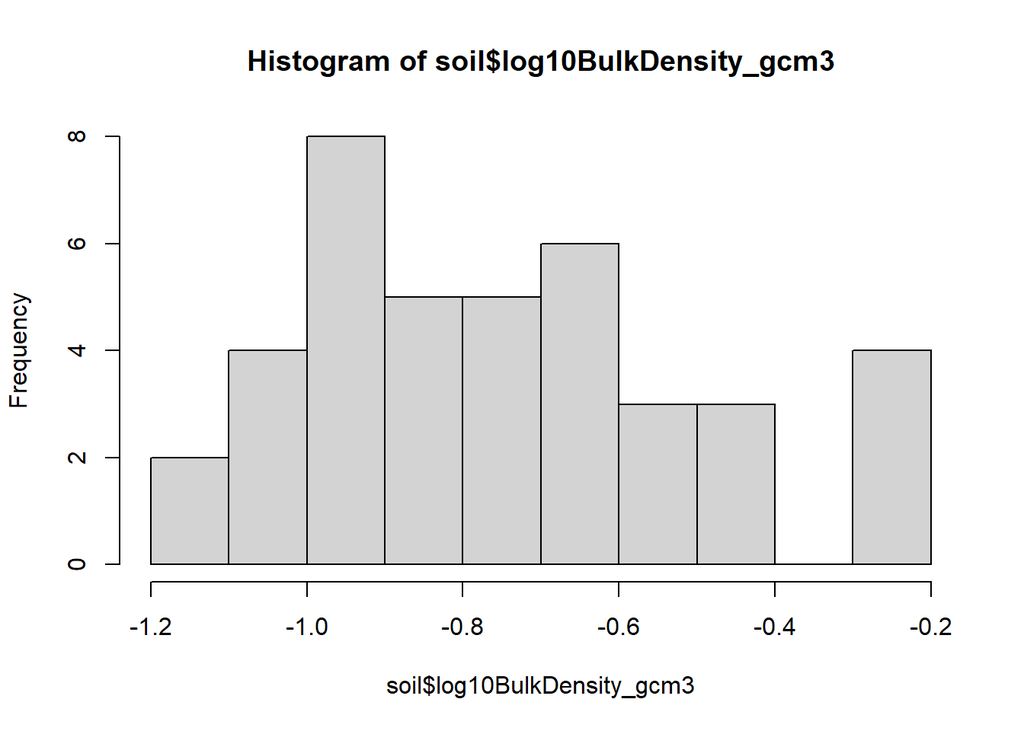

```r
# Log10-transform soil density variable
soil$log10BulkDensity_gcm3 <- log10(soil$BulkDensity_gcm3)
# Inspect the distribution of the log10-transformed organic variable
hist(soil$log10BulkDensity_gcm3)
```

## Challenge 5

> Select the `Treatment` column two different ways.  
> Select all of the rows for which the `Treatment` is “Fire.” (Hint: Logic operators: == equal, != not equal, > greater than, < less than)  
> Assign all of the “Fire” rows to a a new object named fire, and calculate the mean `BulkDensity_gcm3` for burned soils.  
> Change `Treatment` to an ordered factor. Use `str()` to inspect the variable to make sure you were successful.  
> Copy and paste your code to the Challenge 5 question on Brightspace.

**Click for a hint**

```r
# Select the Treatment column
soil[,"Treatment"]
```

```
##  [1] Fire    Fire    Fire    Fire    Fire    Fire    Fire    Fire    Fire
## [10] Fire    Fire    Fire    Fire    Fire    Fire    Fire    Fire    Fire
## [19] Fire    Fire    Control Control Control Control Control Control Control
## [28] Control Control Control Control Control Control Control Control Control
## [37] Control Control Control Control
## Levels: Fire < Control
```

```r
soil$Treatment
```

```
##  [1] Fire    Fire    Fire    Fire    Fire    Fire    Fire    Fire    Fire
## [10] Fire    Fire    Fire    Fire    Fire    Fire    Fire    Fire    Fire
## [19] Fire    Fire    Control Control Control Control Control Control Control
## [28] Control Control Control Control Control Control Control Control Control
## [37] Control Control Control Control
## Levels: Fire < Control
```

```r
# Select rows where Treatment = Fire
soil[soil$Treatment == "Fire",]
```

```
##    Code Treatment        Site TransectPosition_m BulkDensity_gcm3 Moisture
## 1  FA00      Fire Beaver Pond                  0           0.1242   0.9318
## 2  FA05      Fire Beaver Pond                  5           0.2231   0.7136
## 3  FA10      Fire Beaver Pond                 10           0.5693   0.5393
## 4  FA15      Fire Beaver Pond                 15           0.5991   0.4404
## 5  FA20      Fire Beaver Pond                 20           0.5050   0.4560
## 6  FB00      Fire Beaver Pond                  0           0.1056   0.9154
## 7  FB05      Fire Beaver Pond                  5           0.1662   0.7033
## 8  FB10      Fire Beaver Pond                 10           0.2956   0.6224
## 9  FB15      Fire Beaver Pond                 15           0.5408   0.3807
## 10 FB20      Fire Beaver Pond                 20           0.3561   0.5151
## 11 FC00      Fire    Riparian                  0           0.1051   0.8711
## 12 FC05      Fire    Riparian                  5           0.1503   0.4946
## 13 FC10      Fire    Riparian                 10           0.1122   0.6009
## 14 FC15      Fire    Riparian                 15           0.0888   0.7072
```

[output cut: 27 more lines]

```r
# Assign fire rows to object fire
fire <- soil[soil$Treatment == "Fire",]
# Calculate mean bulk density for burned soils
mean(fire$BulkDensity_gcm3)
```

```
## [1] 0.263975
```

```r
# Change Treatment to an ordered factor
soil$Treatment <- ordered(soil$Treatment, levels = c("Fire", "Control"))
# Use str to inspect Treatment variable
str(soil$Treatment)
```

```
##  Ord.factor w/ 2 levels "Fire"<"Control": 1 1 1 1 1 1 1 1 1 1 ...
```

# Graphing in ggplot

Inspecting your data graphically is an important but often overlooked step in statistical analysis. The `ggplot2` package is included in the `tidyverse` package bundle and allows you to quickly graph data in many ways. You can add as many layers of complexity as you like quickly and easily. `ggplot2` graphs can become very complex, but once you have a graph the way you like it, you can easily run the same code for new data.

To build a ggplot, we will use the following basic template that can be used for different types of plots (this is a template; *this will not run as code*):

```r
ggplot(data = <DATA>, mapping = aes(<MAPPINGS>)) +
  <GEOM_FUNCTION>()
```

- use the `ggplot()` function and bind the plot to a specific data frame using the `data` argument

```r
ggplot(data = soil)
```

- define a mapping using the aesthetic `aes()` function, by selecting the variables to be plotted and specifying how to present them in the graph, *e.g.*, as x/y positions or characteristics such as size, shape, color, etc.

```r
ggplot(data = soil, mapping = aes(x = TransectPosition_m, y = BulkDensity_gcm3))
```

- add “geoms,” graphical representations of the data in the plot (points, lines, bars).

> `ggplot2` offers many different geoms. We will use some common ones today, including:
> - `geom_point()` for scatter plots, dot plots, etc.
> - `geom_boxplot()` for…boxplots.
> - `geom_line()` for trend lines, time series, etc.

To add a geom to the plot, use the `+` operator. Because `TransectPosition_m` and `BulkDensity_gcm3` are both continuous variables, let’s use `geom_point()` to make a scatter plot first.

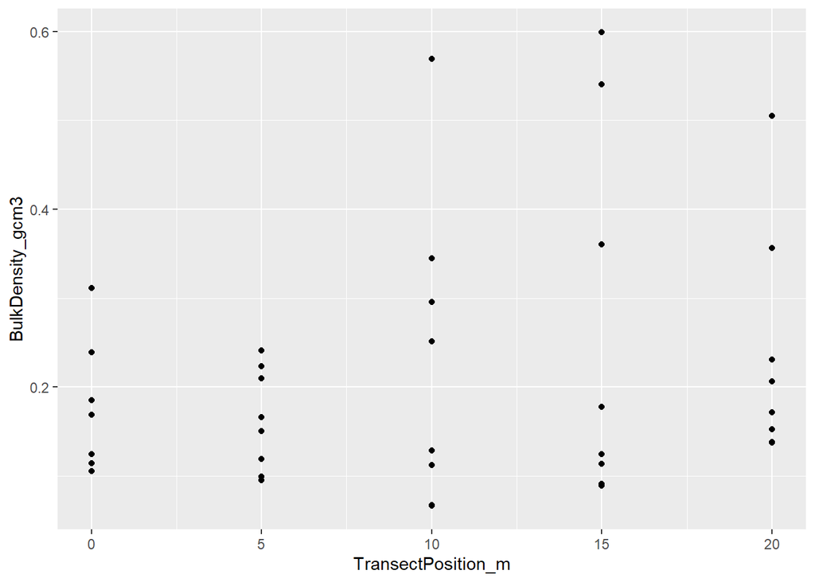

```r
ggplot(data = soil, mapping = aes(x = TransectPosition_m, y = BulkDensity_gcm3)) +
  geom_point()
```

The `+` in the `ggplot2` package is particularly useful because it allows you to modify existing ggplot objects. This means you can easily set up plot templates and conveniently explore different types of plots, so the above plot can also be generated with code like this:

```r
# Assign plot to a variable
soildensity_plot <- ggplot(data = soil, mapping = aes(x = TransectPosition_m,
                                                      y = BulkDensity_gcm3))

# Draw the plot
soildensity_plot +
    geom_point()
```

**Notes**

- Anything you put in the `ggplot()` function can be seen by any geom layers that you add (*i.e.*, these are universal plot settings). This includes the x- and y-axis mapping you set up in `aes()`.
- You can specify mappings for a given geom independently of the mappings defined globally in the `ggplot()` function.
- The `+` sign used to add new layers must be placed at the end of the line containing the previous layer. If, instead, the `+` sign is added at the beginning of the line containing the new layer, `ggplot2` will not add the new layer and will return an error message. The last layer of your plot must not end with a `+`, or ggplot will continue looking for the next line of code for your plot.

```r
# This is the correct syntax for adding layers
soildensity_plot +
  geom_point()

# This will not add the new layer and will return an error message
soildensity_plot
  + geom_point()

# This will not finish running because ggplot is looking for the next plot layer
soildensity_plot +
  geom_point() +
```

## Building your plots iteratively

Building plots with `ggplot2` is typically an iterative process. We start by defining the dataset we’ll use, lay out the axes, and choose a geom:

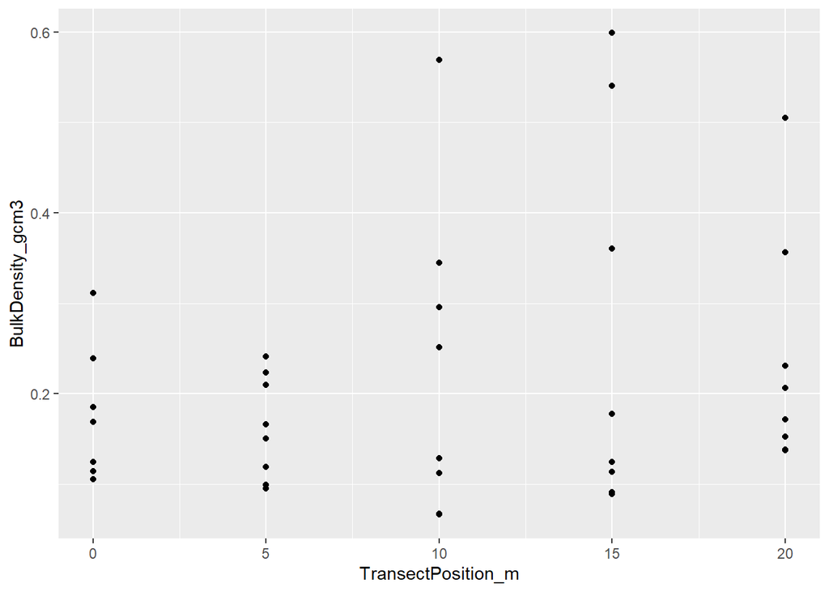

```r
ggplot(data = soil,
       mapping = aes(x = TransectPosition_m, y = BulkDensity_gcm3)) +
  geom_point()
```

Now I want to distinguish between my two treatments. I can add an extra argument to my mapping aesthetics `color =` telling ggplot to use a different color based on my Treatment variable.

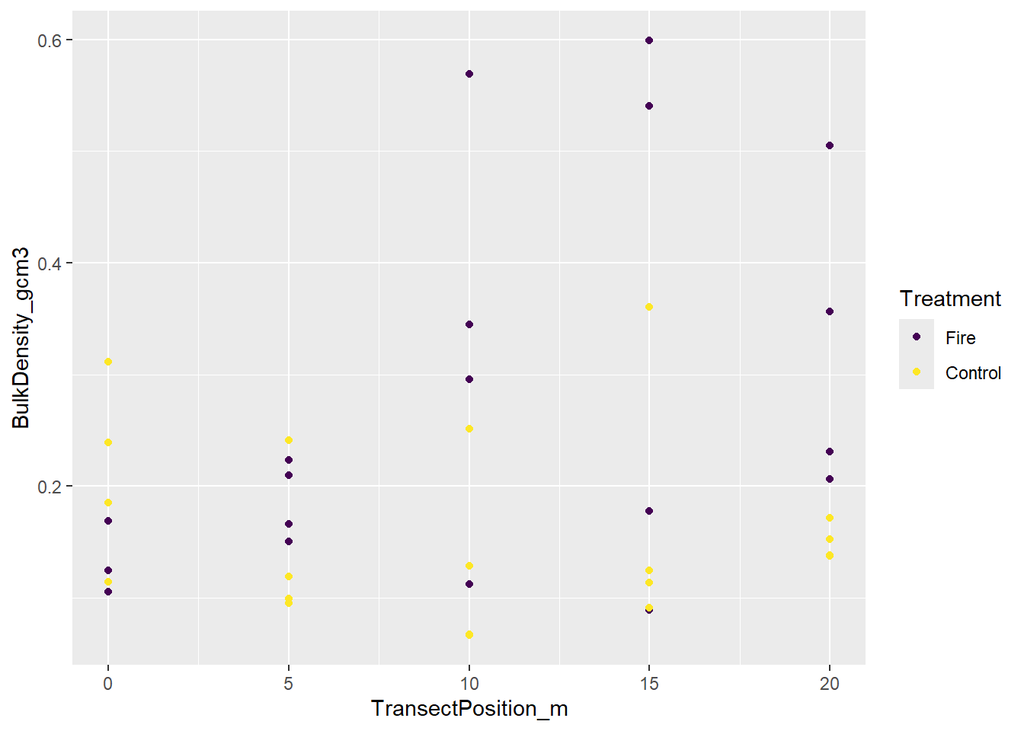

```r
ggplot(data = soil,
       mapping = aes(x = TransectPosition_m, y = BulkDensity_gcm3,
                     color = Treatment)) +
  geom_point()
```

I can add layers that make my axis labels look a bit prettier.

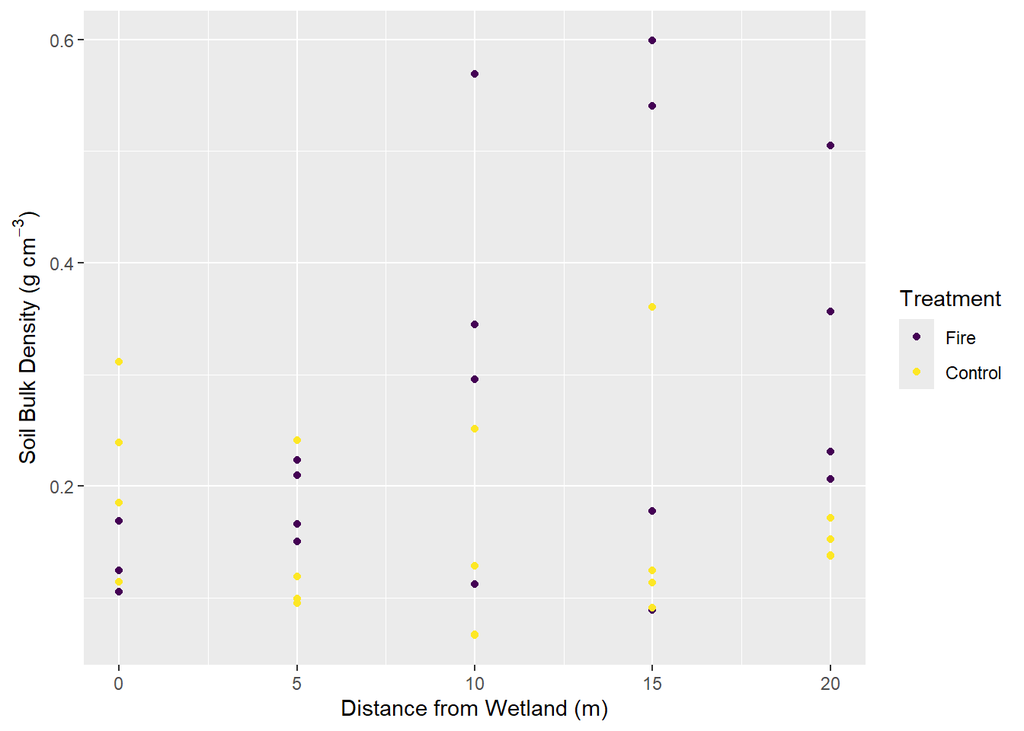

```r
ggplot(data = soil,
       mapping = aes(x = TransectPosition_m, y = BulkDensity_gcm3, color = Treatment)) +
  geom_point() +
  labs(x = "Distance from Wetland (m)",
       y = expression(paste("Soil Bulk Density (g ", cm^-3, ")")))
```

I can change the scaling of axes using the `scale_y_log10()` function.

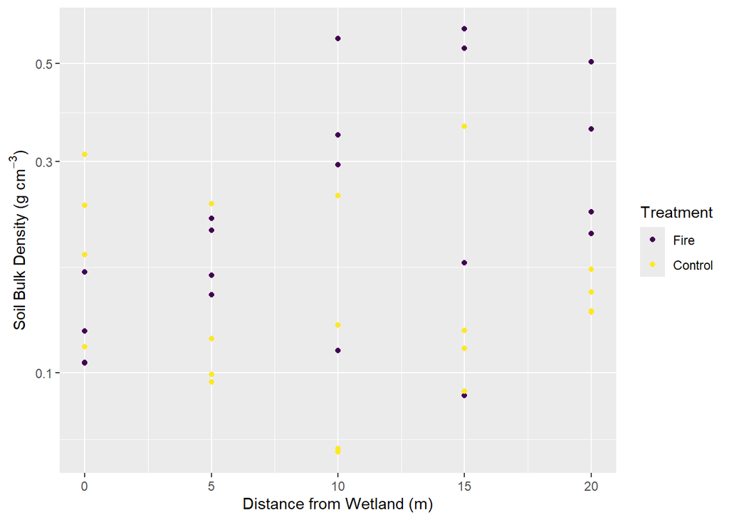

```r
ggplot(data = soil,
       mapping = aes(x = TransectPosition_m, y = BulkDensity_gcm3, color = Treatment)) +
  geom_point() +
  labs(x = "Distance from Wetland (m)",
       y = expression(paste("Soil Bulk Density (g ", cm^-3, ")"))) +
  scale_y_log10()
```

I can add trendlines using the `stat_smooth()` function. Note that I add the argument `method = "lm"` to my function to specify that I want to fit a linear model.

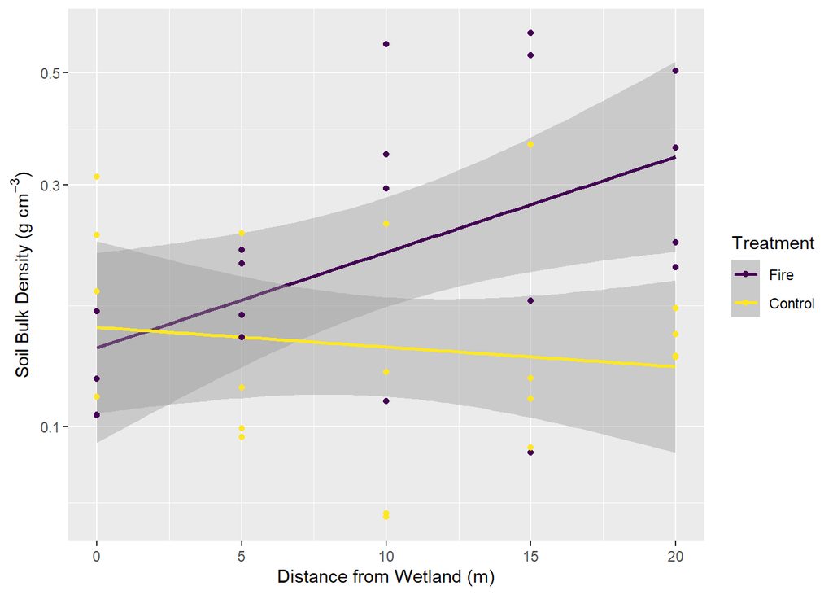

```r
ggplot(data = soil,
       mapping = aes(x = TransectPosition_m, y = BulkDensity_gcm3, color = Treatment)) +
  stat_smooth(method = "lm") +
  geom_point() +
  labs(x = "Distance from Wetland (m)",
       y = expression(paste("Soil Bulk Density (g ", cm^-3, ")"))) +
  scale_y_log10()
```

I can change colors by adding a `scale_color_manual()` function, and I can change the size of my points by adding a `size =` argument to my `geom_point()` function.

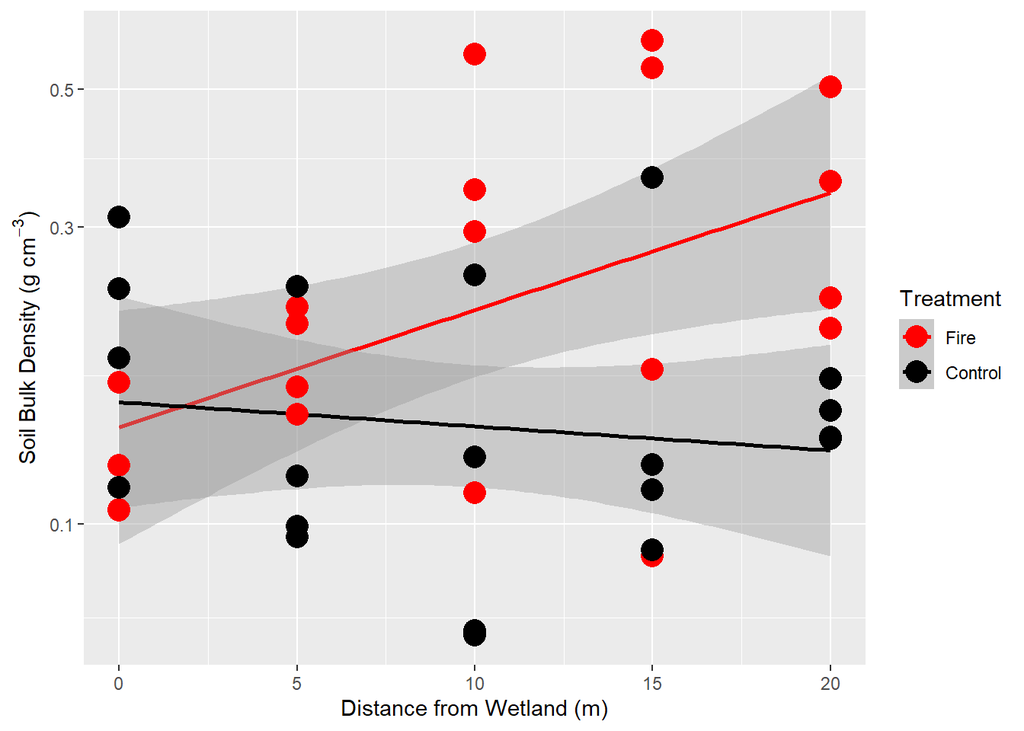

```r
ggplot(data = soil,
       mapping = aes(x = TransectPosition_m, y = BulkDensity_gcm3, color = Treatment)) +
  stat_smooth(method = "lm") +
  geom_point(size = 5) +
  labs(x = "Distance from Wetland (m)",
       y = expression(paste("Soil Bulk Density (g ", cm^-3, ")"))) +
  scale_y_log10() +
  scale_color_manual(values = c("red", "black"))
```

I can separate my sites into two separate panels using the `facet_grid()` function.

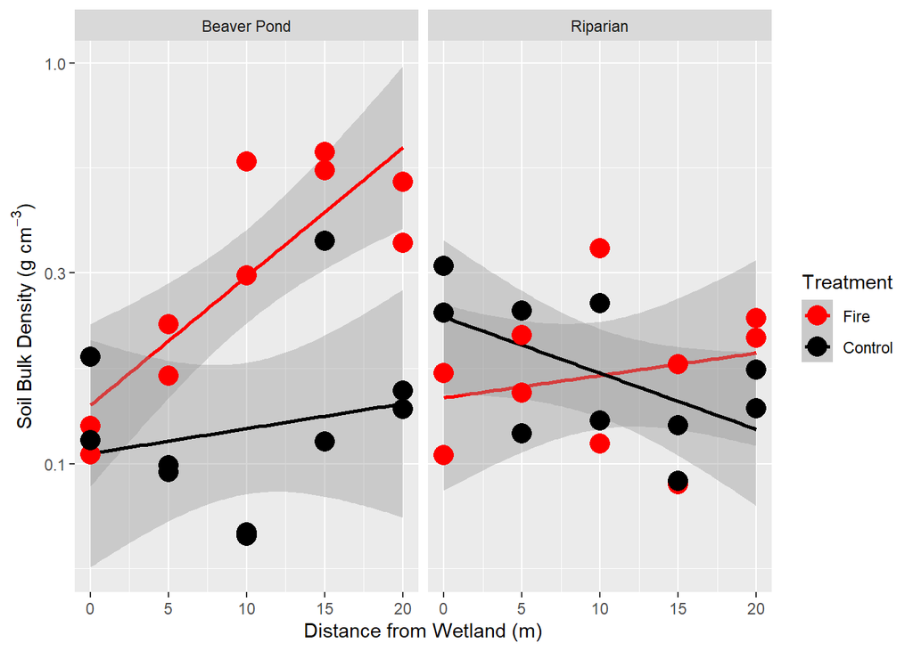

```r
ggplot(data = soil,
       mapping = aes(x = TransectPosition_m, y = BulkDensity_gcm3, color = Treatment)) +
  stat_smooth(method = "lm") +
  geom_point(size = 5) +
  labs(x = "Distance from Wetland (m)",
       y = expression(paste("Soil Bulk Density (g ", cm^-3, ")"))) +
  scale_y_log10() +
  scale_color_manual(values = c("red", "black")) +
  facet_grid(~Site,)
```

And finally, I can add theme functions to change the appearance of graph elements. I like `theme_minimal()` because it’s very clean, but `theme_bw()` and `theme_classic()` are also popular.

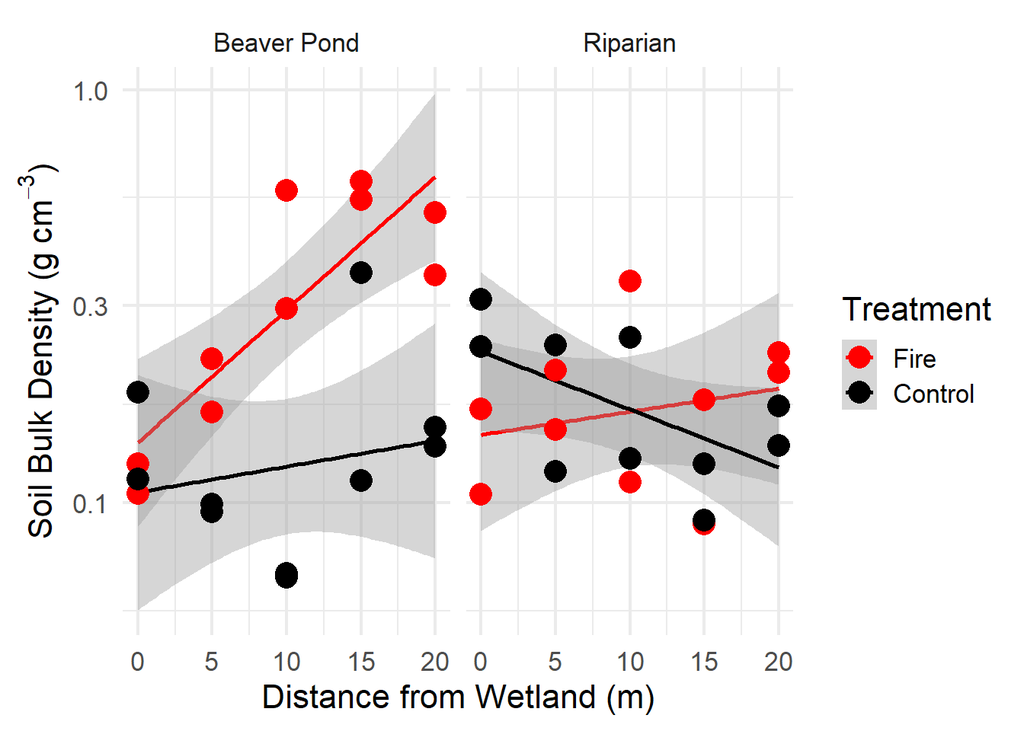

```r
ggplot(data = soil,
       mapping = aes(x = TransectPosition_m, y = BulkDensity_gcm3, color = Treatment)) +
  stat_smooth(method = lm) +
  geom_point(size = 5) +
  labs(x = "Distance from Wetland (m)",
       y = expression(paste("Soil Bulk Density (g ", cm^-3, ")"))) +
  scale_y_log10() +
  scale_color_manual(values = c("red", "black")) +
  facet_grid(~Site,) +
  theme_minimal(base_size = 16)
```

## Graphing line plots with errorbars

Bar graphs and line graphs with error bars like the ones we generated in Excel used to be more complicated to produce in ggplot, primarily because the developer of the package does not like these graphs. However, the `tidyverse` package has several arguments that makes these straightforward to build:

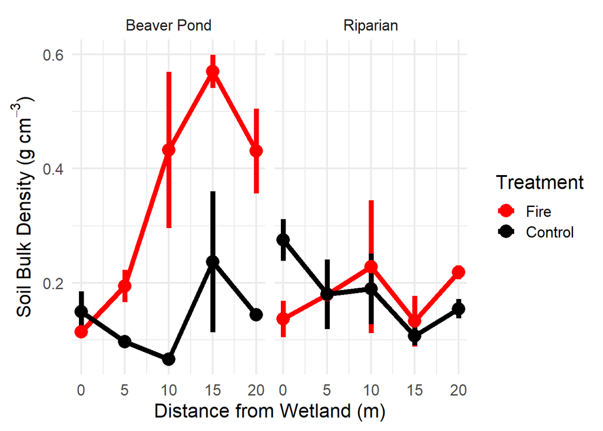

```r
# The following code generates a figure similar to the previous one
# The stat_summary() geom allows you to perform a data summary and specify the geom you wish to plot
# We will add a stat_summary() to add errorbars, a line, and points
ggplot(data = soil,
       mapping = aes(x = TransectPosition_m, y = BulkDensity_gcm3, color = Treatment)) +
  stat_summary(geom = "errorbar", fun.data = "mean_se", width = 0, linewidth = 2) +
  stat_summary(geom = "line", fun = "mean", linewidth = 2) +
  stat_summary(geom = "point", fun = "mean", size = 5) +
  labs(x = "Distance from Wetland (m)",
       y = expression(paste("Soil Bulk Density (g ", cm^-3, ")"))) +
  scale_color_manual(values = c("red", "black")) +
  facet_grid(~Site,) +
  theme_minimal(base_size = 16)
```

## Exporting a graph

You can export a graph directly from the Plots panel. But you should *NEVER* do this. The Export tab in the Plot pane in RStudio will save your plots at low resolution, which will not be accepted by many journals and will not scale well for posters.

Instead, you should use the `ggsave()` function, which allows you to easily change the dimensions and resolution of your plot by adjusting the appropriate arguments (`width`, `height`, and `dpi`). You can also choose the type of file you wish to export by changing the file extension. For example, you may wish to save your file as a .png if you want it to have a transparent background. Some journals may require you to submit images as a .tif. `ggsave()` will export the last plot that you generated, so make sure you run the code for your plot before you run `ggsave()`!

Your new image file will appear in your project folder. You should also see it appear in the Files panel.

```r
#Make bulk density plot
ggplot(data = soil,
       mapping = aes(x = TransectPosition_m, y = BulkDensity_gcm3, color = Treatment)) +
  stat_summary(geom = "errorbar", fun.data = "mean_se", width = 0, linewidth = 2) +
  stat_summary(geom = "line", fun = "mean", linewidth = 2) +
  stat_summary(geom = "point", fun = "mean", size = 5) +
  labs(x = "Distance from Wetland (m)",
       y = expression(paste("Soil Bulk Density (g ", cm^-3, ")"))) +
  scale_color_manual(values = c("red", "black")) +
  facet_grid(~Site,) +
  theme_minimal(base_size = 16)
#Export bulk density plot with ggsave()
ggsave("AltonaSoil_Dens.jpg", width = 8, height = 4, dpi = 300)
```

## Challenge 6

> Use the code above as a template to create either a scatterplot or line graph that compares changes in soil density between fire and control sites and riparian and beaver-pond sites along the wetland-upland gradient. Use the `ggsave("file.jpg")` function to save your plot as a .jpg file.  
> Copy and paste the code, and make any necessary changes, to create the same graph for Moisture and Organic variables (be sure to rename the y-axis appropriately.) Use `ggsave()` to export your graphs. (Be sure to change the file name in the `ggsave()` function when saving a new image or it will overwrite the last image!)  
> Upload your graphs using the html editor in the Challenge 6 question on Brightspace.

**Click for a hint**

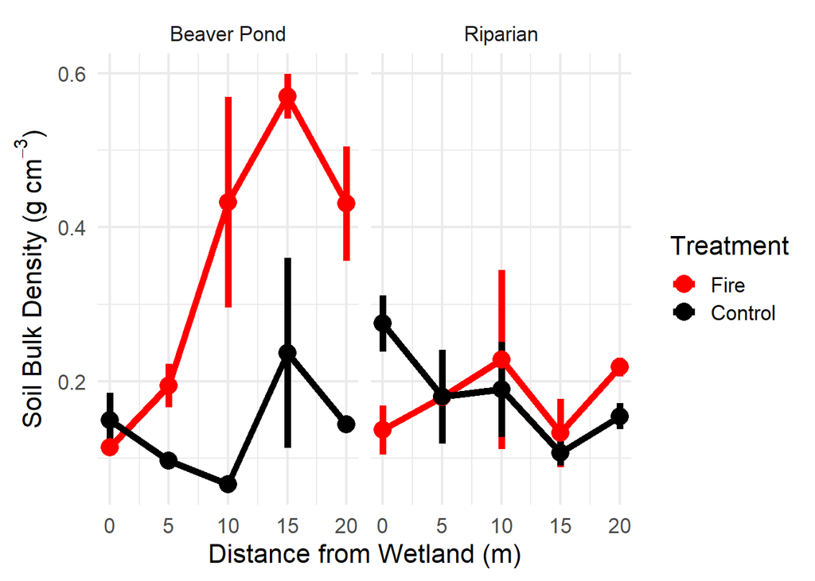

```r
# Make bulk density plot
ggplot(data = soil,
       mapping = aes(x = TransectPosition_m, y = BulkDensity_gcm3, color = Treatment)) +
  stat_summary(geom = "errorbar", fun.data = "mean_se", width = 0, linewidth = 2) +
  stat_summary(geom = "line", fun = "mean", linewidth = 2) +
  stat_summary(geom = "point", fun = "mean", size = 5) +
  labs(x = "Distance from Wetland (m)",
       y = expression(paste("Soil Bulk Density (g ", cm^-3, ")"))) +
  scale_color_manual(values = c("red", "black")) +
  facet_grid(~Site,) +
  theme_minimal(base_size = 16)
```

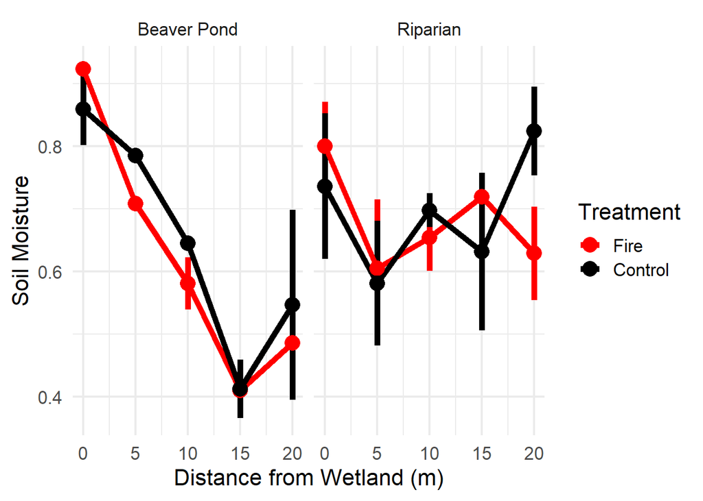

```r
# Export bulk density plot with ggsave()
ggsave("AltonaSoil_Dens.jpg", width = 8, height = 4, dpi = 300)

# Make moisture plot
ggplot(data = soil,
       mapping = aes(x = TransectPosition_m, y = Moisture, color = Treatment)) +
  stat_summary(geom = "errorbar", fun.data = "mean_se", width = 0, linewidth = 2) +
  stat_summary(geom = "line", fun = "mean", linewidth = 2) +
  stat_summary(geom = "point", fun = "mean", size = 5) +
  labs(x = "Distance from Wetland (m)",
       y = "Soil Moisture") +
  scale_color_manual(values = c("red", "black")) +
  facet_grid(~Site,) +
  theme_minimal(base_size = 16)
```

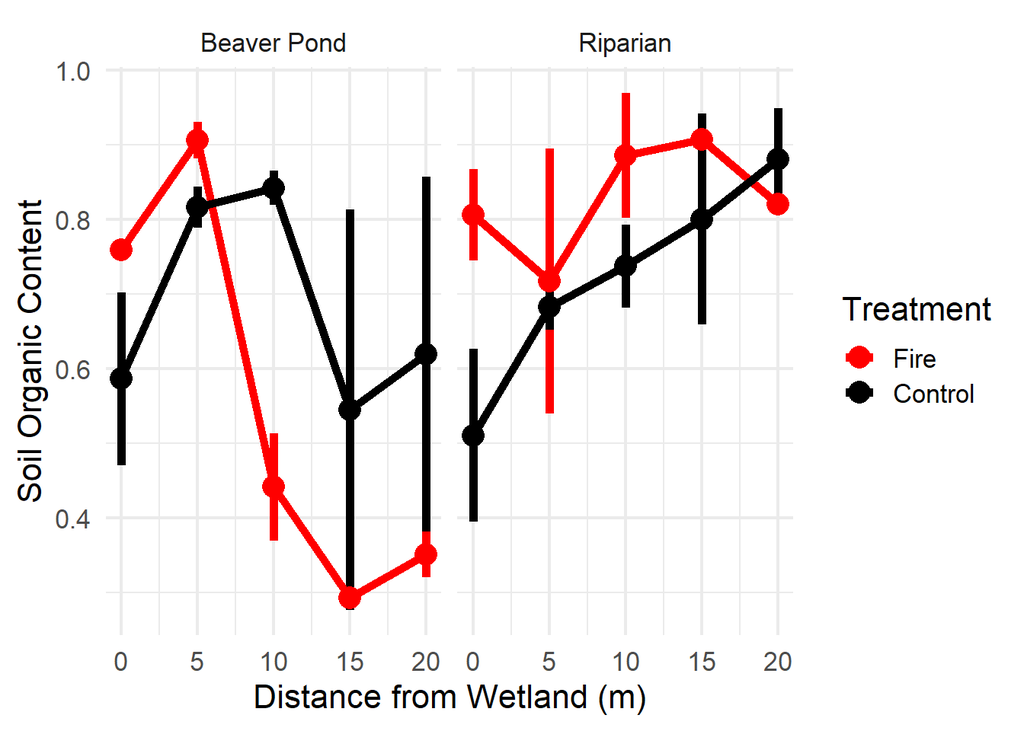

```r
# Export moisture plot with ggsave()
ggsave("AltonaSoil_Mois.jpg", width = 8, height = 4, dpi = 300)

# Make organic plot
ggplot(data = soil,
       mapping = aes(x = TransectPosition_m, y = Organic, color = Treatment)) +
  stat_summary(geom = "errorbar", fun.data = "mean_se", width = 0, linewidth = 2) +
  stat_summary(geom = "line", fun = "mean", linewidth = 2) +
  stat_summary(geom = "point", fun = "mean", size = 5) +
  labs(x = "Distance from Wetland (m)",
       y = "Soil Organic Content") +
  scale_color_manual(values = c("red", "black")) +
  facet_grid(~Site,) +
  theme_minimal(base_size = 16)
```

```r
# Export organic content plot with ggsave()
ggsave("AltonaSoil_Org.jpg", width = 8, height = 4, dpi = 300)
```

## Graphing boxplots and bar graphs in ggplot2

Boxplots, which show the median, quartiles, range, and outliers for a dataset, are easy to graph in ggplot2 using the `geom_boxplot()` function. Note that the `geom_boxplot()` function is expecting a grouping variable on the x-axis. You can transform year from a numeric variable to a factor using the `as.factor()` function.

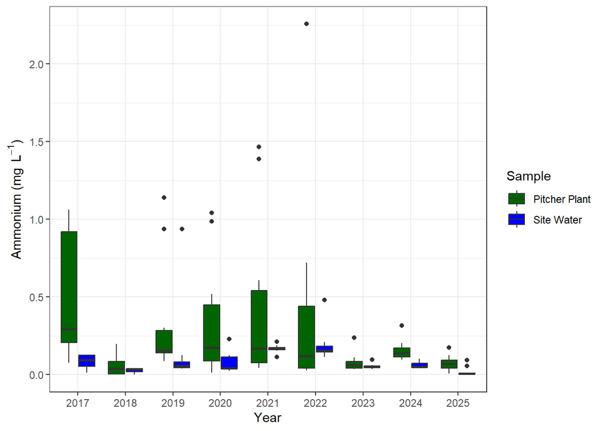

```r
# Create boxplot of ammonium concentrations for pitcher plant and site water
ggplot(nut, aes(x = as.factor(Year), y = Ammonium_mgL, fill = Sample)) +
  geom_boxplot() +
  labs(x = "Year",
       y = expression(paste("Ammonium (mg ", L^-1, ")"))) +
  scale_fill_manual(values = c("darkgreen", "blue")) +
  theme_bw()
```

```r
# Export plot as jpg
ggsave("PP_Nutrients.jpg", height = 4, width = 6, dpi = 300)
```

Alternatively, you could create a line graph with error bars, as we did for the soil variables. Here, the stat_summary() function is looking for a numeric variable on the x-axis, so we do not need to transform Year. You can customize the x axis using the scale_x_continuous() function. Here I use that function to set limits for the axis and indicate which tick marks I want to show up.

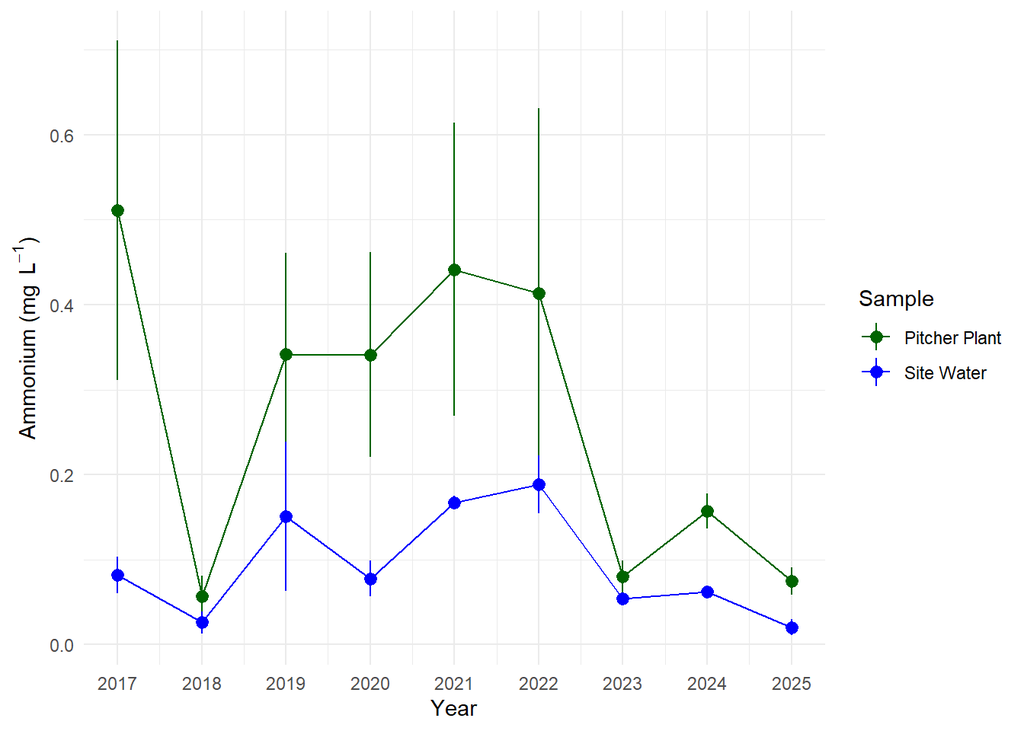

```r
# Plot line graph
ggplot(nut, aes(x = Year, y = Ammonium_mgL, color = Sample)) +
  stat_summary(geom = "line", fun = "mean") +
  stat_summary(fun.data = "mean_se") +
  labs(x = "Year",
       y = expression(paste("Ammonium (mg ", L^-1, ")"))) +
  scale_color_manual(values = c("darkgreen", "blue")) +
  scale_x_continuous(limits = c(2017, 2025), breaks = seq(2017, 2025, 1)) +
  theme_minimal()
```

```r
# Export plot as jpg
ggsave("PP_Nutrients_Line.jpg", height = 4, width = 6, dpi = 300)
```

## Challenge 7

> Use the code above as a template to create a plot that compares ammonium concentrations between pitcher plants and site water, and among sample years. Use the `ggsave()` function to save your image.  
> Based on what you’ve learned so far, create a simple scatterplot to look for a relationship between `Ammonium_mgL` and `Invertebrates` in the `com` dataframe. Add a linear trendline. Use the `ggsave()` function to save your image.  
> Upload your graphs using the html editor in the Challenge 7 question on Brightspace.

**Click for a hint**

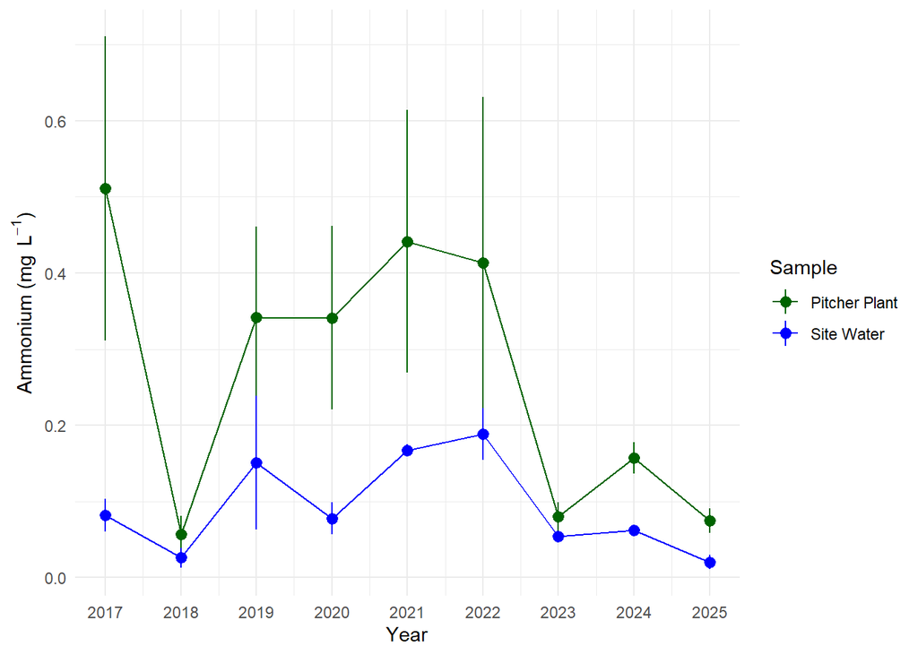

```r
# Plot line graph
ggplot(nut, aes(x = Year, y = Ammonium_mgL, color = Sample)) +
  stat_summary(geom = "line", fun = "mean") +
  stat_summary(fun.data = "mean_se") +
  labs(x = "Year",
       y = expression(paste("Ammonium (mg ", L^-1, ")"))) +
  scale_color_manual(values = c("darkgreen", "blue")) +
  scale_x_continuous(limits = c(2017, 2025), breaks = seq(2017, 2025, 1)) +
  theme_minimal()
```

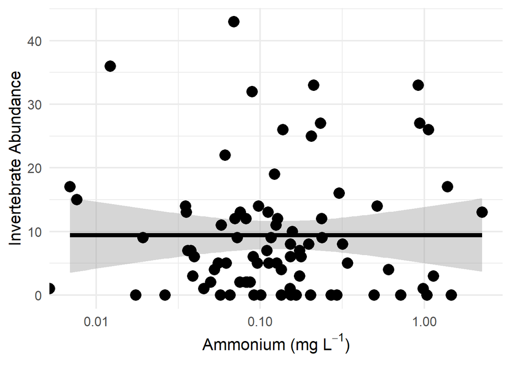

```r
# Export plot as jpg
ggsave("PP_Nutrients_Line.jpg", height = 4, width = 6, dpi = 300)

# Plot scatterplot
ggplot(com, aes(x = Ammonium_mgL, y = Invertebrates)) +
  stat_smooth(method = "lm", size = 2, color = "black") +
  geom_point(size = 5) +
  labs(x = expression(paste("Ammonium (mg ", L^-1, ")")),
       y = "Invertebrate Abundance") +
  theme_minimal(base_size = 16) +
  scale_x_log10()
```

```r
# Export plot as jpg
ggsave("PP_Nutrients_Invert.jpg")
```

# Reshaping data

A complete exploration of data reshaping using tools in `dplyr`, a key package in the tidyverse, is outside the scope of this workshop. However, I will quickly show you how to reshape data to go from a “short” to a “long” format using the `pivot_longer()` function to make a graph for the macroinvertebrate data.

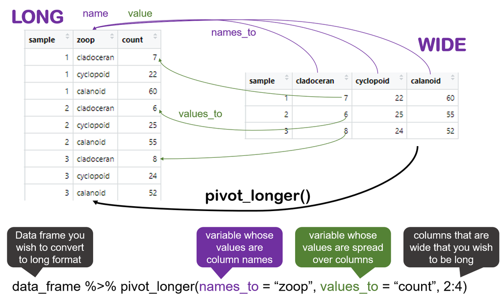

The code below uses pipes `%>%`, which run multiple commands on a data frame in order. You can read a pipe as meaning “and then.” So in the code below, I will select the first 35 columns of the data frame using `select()` *and then* gather the taxon data (columns 4-35) into two columns using `pivot_longer()`, one column for the taxon and another for the count. *And then* I will exclude taxa that were absent using `na.omit()`, which drops rows with missing values, or `NA`s. You can type a pipe quickly by holding `Ctrl` + `Shift` + `m`.

```r
# create new dataframe for long-format data
maclong <- mac %>%
  # select columns that have taxon information and not health-index columns
  select(1:35) %>%
  # change to long format
  pivot_longer(names_to = "taxon", values_to = "count", 4:35) %>%
  # remove missing values
  na.omit()
```

## Summarizing data

Finally, I will group by taxa and compute mean counts using `group_by()` and then `summarize()`. Note that you could use as many grouping variables as you want to make the graph that you want to make; this is similar to the pivot tables we made in Excel only much quicker and more flexible.

```r
macsum <- maclong %>%
  group_by(taxon) %>%
  summarize(count = mean(count, na.rm = T))
```

## Flipping axis

Now I will set up a bar graph to examine counts for my various taxa. I will place the grouping variable on the x-axis, and the count on the y-axis.

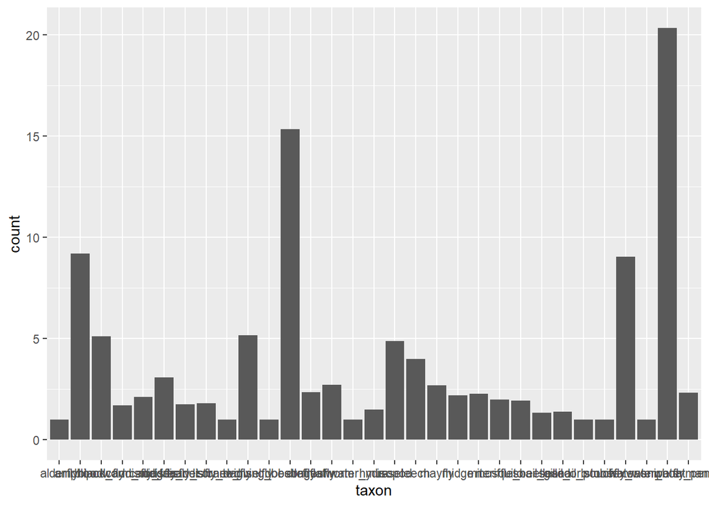

```r
ggplot(macsum, aes(x = taxon, y = count)) +
  geom_bar(stat = "identity")
```

Well that looks awful. The taxa names are so long that I can’t read any of them, and they’re in alphabetical order, which is biologically meaningless. Let’s fix the first problem. You can easily flip the x and y axis using the function `coord_flip()`. This is useful when you have long group names OR you would like your response variable to appear vertically (*e.g.*, I do this all the time for depth profiles.) It maintains your original relationship between the x and y variable as specified in `aes()`, but switches their position on the graph.

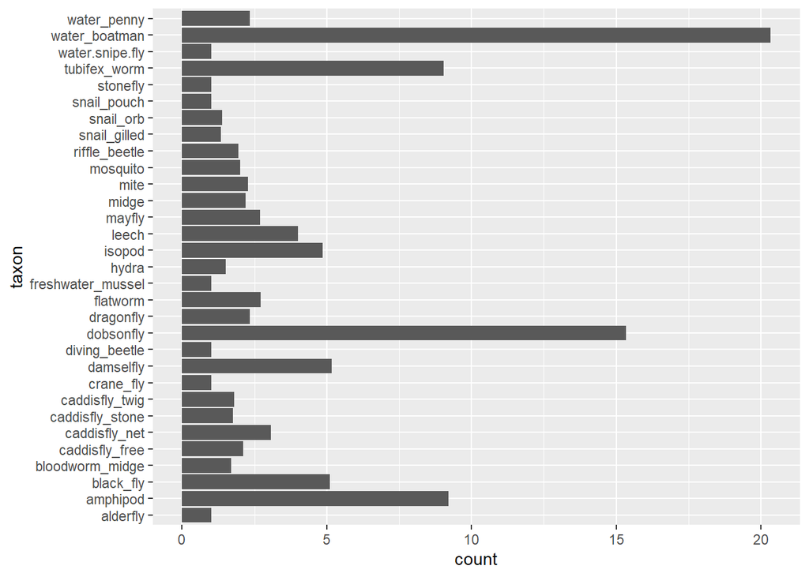

```r
ggplot(macsum, aes(x = taxon, y = count)) +
  geom_bar(stat = "identity") +
  coord_flip()
```

That looks a bit better. Now I can read the taxa names. But I would also like to reorder them based on which are most common. I can do this using the `reorder()` function.

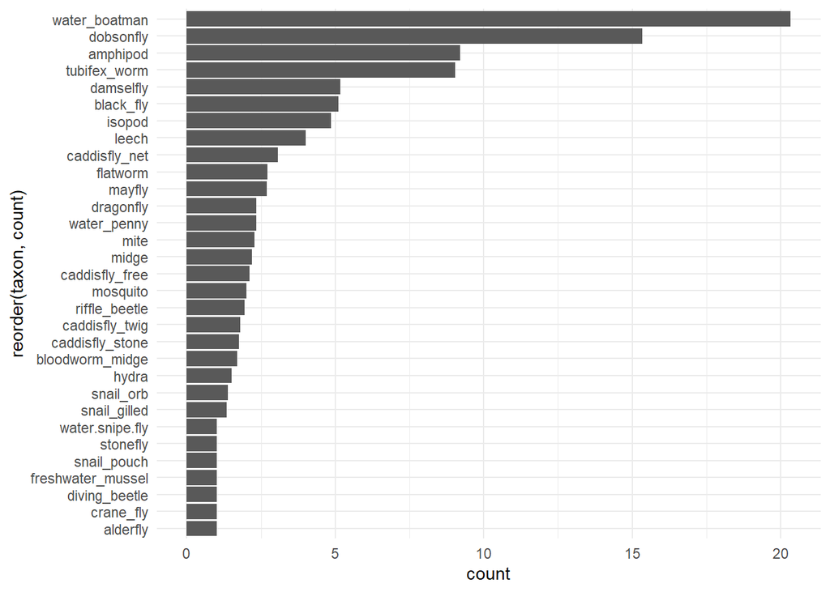

```r
ggplot(macsum, aes(x = reorder(taxon, count), y = count)) +
  geom_bar(stat = "identity") +
  coord_flip() +
  theme_minimal() +
  theme(legend.position = "none")
```

On your own, try to make a new summary data frame, grouping by habitat in addition to taxon, and recreate this graph with two facets for the two habitat types.

**Click for a hint**

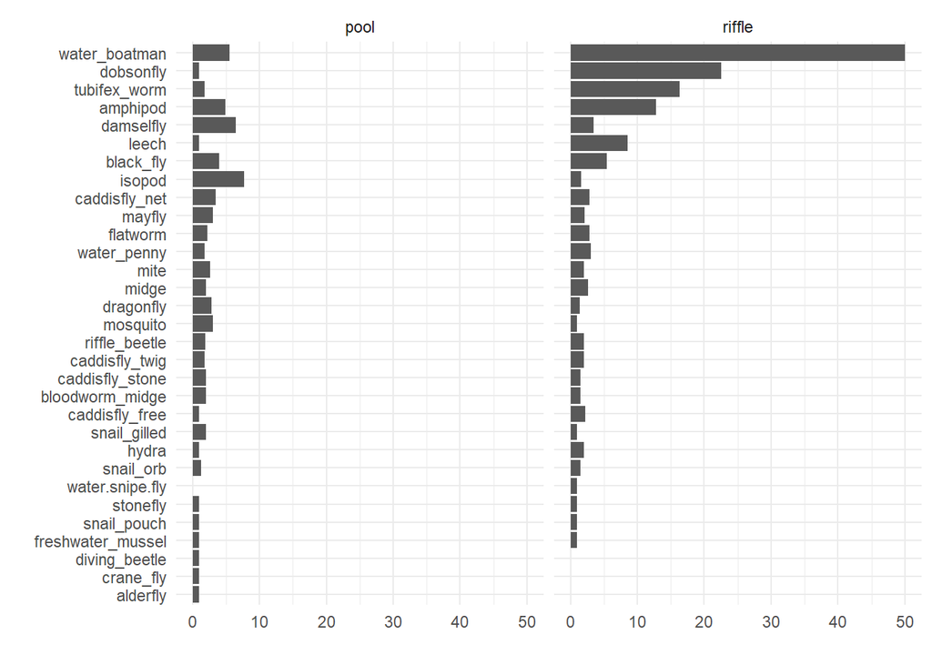

```r
# create summary table
machab <- maclong %>%
  group_by(taxon, habitat) %>%
  summarize(count = mean(count, na.rm = T))

# create graph
ggplot(machab, aes(x = reorder(taxon, count), y = count)) +
  geom_bar(stat = "identity") +
  coord_flip() +
  theme_minimal() +
  facet_grid(.~habitat) +
  labs(x = "", y = "")
```

# Statistical analysis in R

Now that you’ve learned the ins and outs of ggplot, the next part should be easy. We will run through a few of the more common statistical tests that you may need to run for your data analysis.

## Perform a T-test

You can perform a t-test using the function `t.test()`. The form is `t.test(DepVar~IndepVar, data = data)`. The default is a two-tailed t-test. You can add the argument `alternative = "greater"` to specify a one-tailed test. We will perform a t-test on our pitcher plant nutrient data from 2025 only. We will first create a new data frame containing only 2025 data, and then reference that data frame to perform the test.

```r
# Create data frame for 2025 data only
PP2025 <- nut[nut$Year == "2025",]
# Specify the model that you want to test; to perform a one-tailed t-test, add argument alternative = "greater"
mod_nut <- t.test(Ammonium_mgL~Sample, data = PP2025,
                  alternative = "greater")
# Call results of model
mod_nut
```

```
##
##  Welch Two Sample t-test
##
## data:  Ammonium_mgL by Sample
## t = 2.9335, df = 14.906, p-value = 0.005164
## alternative hypothesis: true difference in means between group Pitcher Plant and group Site Water is greater than 0
## 95 percent confidence interval:
##  0.02182453        Inf
## sample estimates:
## mean in group Pitcher Plant    mean in group Site Water
##                     0.07438                     0.02011
```

## Challenge 8

> Using the code above, perform a t-test to compare `Ammonium_mgL` between pitcher plants and site water for the 2025 data only.  
> What is the t-statistic?  
> How many degrees of freedom did the test include?  
> What is the p-value?  
> If we set the threshhold for “significance” at alpha = 0.05, what can you conclude based on this p-value?  
> Enter your answers into the Challenge 8 question on Brightspace.

## Perform an Analysis of Variance (ANOVA)

The simplest way to perform an ANOVA in R is to use the `aov()` function. The form of the `aov()` function is `aov(DepVar~IndepVar, data = data)`. For significant effects, you can perform a posthoc test using the function `TukeyHSD()`. We will run a two-way ANOVA to test for a difference in soil bulk density between Treatments and Sites. Note that we used the log10-transformed bulk density variable in the model.

```r
#Specify linear model in the form y~x
mod_dens <- aov(log10(BulkDensity_gcm3)~Treatment*Site, data = soil)
summary(mod_dens)
```

```
##                Df Sum Sq Mean Sq F value Pr(>F)
## Treatment       1 0.3498  0.3498   7.342 0.0102 *
## Site            1 0.0294  0.0294   0.618 0.4371
## Treatment:Site  1 0.3705  0.3705   7.777 0.0084 **
## Residuals      36 1.7153  0.0476
## ---
## Signif. codes:  0 '***' 0.001 '**' 0.01 '*' 0.05 '.' 0.1 ' ' 1
```

```r
TukeyHSD(mod_dens)
```

```
##   Tukey multiple comparisons of means
##     95% family-wise confidence level
##
## Fit: aov(formula = log10(BulkDensity_gcm3) ~ Treatment * Site, data = soil)
##
## $Treatment
##                    diff        lwr        upr     p adj
## Control-Fire -0.1870381 -0.3270308 -0.0470453 0.0102487
##
## $Site
##                             diff        lwr        upr     p adj
## Riparian-Beaver Pond -0.05424675 -0.1942395 0.08574602 0.4370801
##
## $`Treatment:Site`
##                                              diff        lwr         upr
## Control:Beaver Pond-Fire:Beaver Pond -0.379533010 -0.6424421 -0.11662397
## Fire:Riparian-Fire:Beaver Pond       -0.246741692 -0.5096507  0.01616735
## Control:Riparian-Fire:Beaver Pond    -0.241284821 -0.5041939  0.02162422
## Fire:Riparian-Control:Beaver Pond     0.132791319 -0.1301177  0.39570036
## Control:Riparian-Control:Beaver Pond  0.138248190 -0.1246608  0.40115723
## Control:Riparian-Fire:Riparian        0.005456871 -0.2574522  0.26836591
##                                          p adj
## Control:Beaver Pond-Fire:Beaver Pond 0.0022626
## Fire:Riparian-Fire:Beaver Pond       0.0724475
## Control:Riparian-Fire:Beaver Pond    0.0817695
## Fire:Riparian-Control:Beaver Pond    0.5317564
## Control:Riparian-Control:Beaver Pond 0.4977519
## Control:Riparian-Fire:Riparian       0.9999360
```

## Challenge 9

> Using the code above, perform an ANOVA to compare `BulkDensity_gcm3` between fire and control sites and between beaver and riparian sites. Be sure to log10-transform the bulk density variable.  
> What is the p-value for the interaction between site and treatment?  
> Based on this p-value, does the difference between fire and control sites differ between the two sampling locations? Explain your answer.  
> Enter your answers into the Challenge 9 question on Brightspace.

Now we will run an Analysis of Covariance (ANCOVA) to test for a difference in soil density between burn and control sites across our wetland gradient. An ANCOVA is similar to an ANOVA, except that it contains one independent variable that is a continuous variable, *i.e.*, `TransectPosition_m`. An ANCOVA tests the null hypothesis that there is no difference in the relationship between the x and y variable among different groups. In this case, we are testing the null hypothesis that there is no difference in the relationship between soil bulk density and distance from the wetland edge between the burned and unburned watersheds.

First, let’s run this test for the riparian sites only.

```r
# Create a data frame that contains the riparian sites only
rip <- soil[soil$Site == "Riparian",]
# Specify model
mod_dens_riparian <- aov(log10(BulkDensity_gcm3)~Treatment*TransectPosition_m, data = rip)
# Call output of model
summary(mod_dens_riparian)
```

```
##                              Df Sum Sq Mean Sq F value Pr(>F)
## Treatment                     1 0.0001 0.00015   0.005 0.9431
## TransectPosition_m            1 0.0178 0.01777   0.626 0.4403
## Treatment:TransectPosition_m  1 0.0959 0.09591   3.382 0.0846 .
## Residuals                    16 0.4538 0.02836
## ---
## Signif. codes:  0 '***' 0.001 '**' 0.01 '*' 0.05 '.' 0.1 ' ' 1
```

Now, let’s run this test for the beaver pond sites only.

```r
# Create a data frame that contains the beaver pond sites only
bea <- soil[soil$Site == "Beaver Pond",]
# Specify model
mod_dens_beaver <- aov(log10(BulkDensity_gcm3)~Treatment*TransectPosition_m, data = bea)
# Call output of model
summary(mod_dens_beaver)
```

```
##                              Df Sum Sq Mean Sq F value   Pr(>F)
## Treatment                     1 0.7202  0.7202  18.849 0.000505 ***
## TransectPosition_m            1 0.3685  0.3685   9.644 0.006802 **
## Treatment:TransectPosition_m  1 0.1679  0.1679   4.395 0.052289 .
## Residuals                    16 0.6114  0.0382
## ---
## Signif. codes:  0 '***' 0.001 '**' 0.01 '*' 0.05 '.' 0.1 ' ' 1
```

## Challenge 10

> Perform the ANCOVA tests using the code above.  
> For each site, does the slope of the relationship between `TransectPosition_m` and `BulkDensity_gcm3` differ between the fire and control treatments? How do you know?  
> Is this result consistent with your figure of Bulk Density (scatterplot)?  
> Enter your answers into the Challenge 10 question on Brightspace.

## Perform a Linear Regression

You can perform a linear regression in R using the function `lm()`. The form is `lm(DepVar~IndepVar, data = data)`. (This should be looking familiar by now!) Note that this method only works if two variables are linearly related.

Let’s run a linear model to test for a relationship between ammonium concentration in pitcher plant leaves and the number of invertebrates in the pitcher plant community for the 2025 data only.

```r
# First, I want to select values in the com data frame from 2025 only
com2025 <- com[com$Year == 2025,]
# Then I want to specify the model
mod_nut_ins <- lm(Invertebrates~Ammonium_mgL, data = com2025)
# Show model output
summary(mod_nut_ins)
```

```
##
## Call:
## lm(formula = Invertebrates ~ Ammonium_mgL, data = com2025)
##
## Residuals:
##    Min     1Q Median     3Q    Max
## -7.151 -3.385 -0.659  2.310 11.875
##
## Coefficients:
##              Estimate Std. Error t value Pr(>|t|)
## (Intercept)    13.000      3.324   3.912  0.00447 **
## Ammonium_mgL  -47.062     37.695  -1.249  0.24715
## ---
## Signif. codes:  0 '***' 0.001 '**' 0.01 '*' 0.05 '.' 0.1 ' ' 1
##
## Residual standard error: 5.644 on 8 degrees of freedom
## Multiple R-squared:  0.1631, Adjusted R-squared:  0.05846
## F-statistic: 1.559 on 1 and 8 DF,  p-value: 0.2471
```

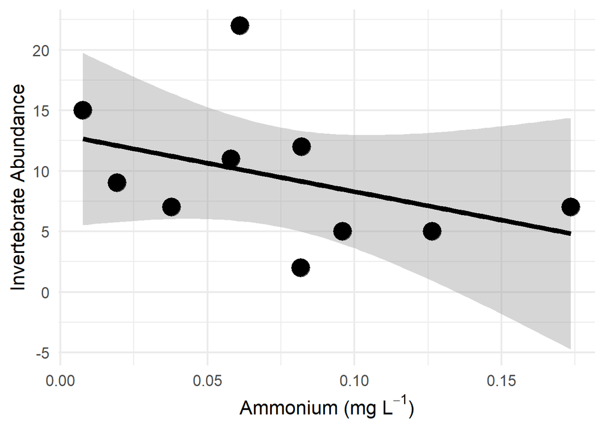

```r
# Create a quick scatterplot showing the relationship
ggplot(com2025, aes(x = Ammonium_mgL, y = Invertebrates)) +
  stat_smooth(method = "lm", size = 2, color = "black") +
  geom_point(size = 7, color = "black") +
  labs(x = expression(paste("Ammonium (mg ", L^-1, ")")),
       y = "Invertebrate Abundance") +
  theme_minimal(base_size = 16)
```

## Challenge 11

> Perform the linear regression using the code above.  
> What is the p-value for the regression?  
> What is the R<sup>2</sup> value for the regression?  
> What is the slope of the regression?  
> What can you conclude about the relationship between ammonium concentration and invertebrate abundance in pitcher plant leaves? Explain your answer.  
> Enter your answers into the Challenge 11 question on Brightspace.